# feature: an R package for feature significance for multivariate kernel density estimation

Tarn Duong https://mvstat.net/tduong/

10 February 2021

## Univariate data example

[figure not shown]

```r
library(feature)
data(earthquake)
eq3 <- log10(-earthquake[,3])
eq3.fs <- featureSignif(eq3, bw=0.1)
plot(eq3.fs, xlab="-log(-depth)", addSignifGradRegion=TRUE, addData=TRUE)
```

```r
xlim <- par()$usr[1:2]  ## save x-axis limits to align following SiZer plot
```

Below this is the SiZer plot of Chaudhuri & Marron (1999). In the SiZer plot, blue indicates significantly increasing gradient, red is significantly decreasing gradient, purple is non-significant gradient and grey is data too sparse for reliable estimation. The horizontal black line is for the bandwidth 0.1.

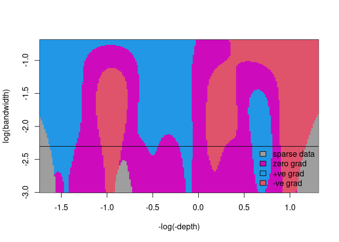

```r
eq3.SiZer <- SiZer(eq3, xlim=xlim, bw=c(0.05, 0.5), xlab="-log(-depth)")
abline(h=log(0.1))
```

## Bivariate data example

For bivariate data, we look at an Old Faithful geyser data set, in the `MASS` library. The horizontal axis is the `waiting` time (in minutes) between two eruptions, and the vertical axis is the `duration` time (in minutes) of an eruption. Below is a kernel density estimate with bandwidth (4.5, 0.37) with the significant curvature regions in blue superimposed.

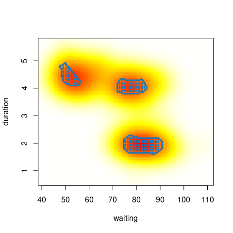

```r
library(MASS)
data(geyser)
geyser.fs <- featureSignif(geyser, bw=c(4.5, 0.37))
plot(geyser.fs, addSignifCurvRegion=TRUE)
```

A variation on plotting the significant regions is to plot the data points which fall inside these regions: significant curvature data points are in blue.

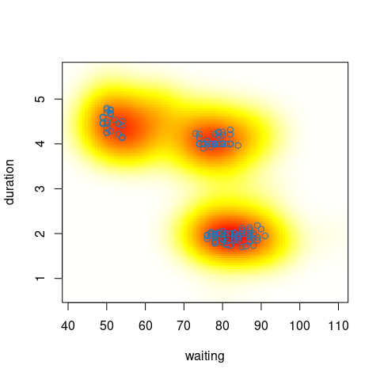

```r
plot(geyser.fs, addSignifCurvData=TRUE)
```

## Trivariate data example

For trivariate data, we return to the earthquake data set. Below are the significant curvature regions in blue with bandwidth (0.06, 0.06, 0.05).

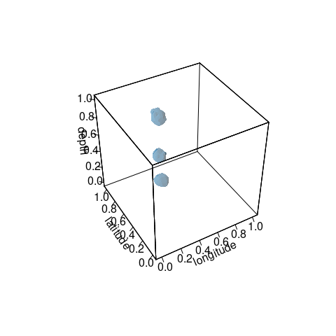

```r
data(earthquake)
earthquake[,3] <- -log10(-earthquake[,3])
earthquake.fs <- featureSignif(earthquake, scaleData=TRUE, bw=c(0.06, 0.06, 0.05))
plot(earthquake.fs, addKDE=FALSE, addSignifCurvRegion=TRUE)
```

The result of `featureSignif` is an object of class `fs` which is a list with fields

```r
names(earthquake.fs)
```

```
#>  [1] "x"              "names"          "bw"             "fhat"
#>  [5] "grad"           "curv"           "gradData"       "gradDataPoints"
#>  [9] "curvData"       "curvDataPoints"
```

where

- `x` is the data
- `names` are the name labels used for plotting
- `bw` is the bandwidth
- `fhat` is the kernel density estimate
- `grad` is the logical matrix indicating signficant gradient on a grid
- `curv` is the logical matrix indicating signficant curvature on a grid
- `gradData` is the logical vector indicating signficant gradient data points
- `gradDataPoints` are the signficant gradient data points
- `curvData` is the logical vector indicating signficant curvature data points
- `curvDataPoints` are the signficant curvature data points.

## Functionality not documented in this vignette

The function `featureSignifGUI` provides interactive feature significance via `tcltk` windows but the latter are not integrated with `rmarkdown`. See `?featureSignifGUI`.

## References

Chaudhuri, P. and Marron, J. S. (1999). SiZer for exploration of structures in curves. *Journal of the American Statistical Association*, **94**, 807-823.

Duong, T., Cowling, A., Koch, I., and Wand, M. P. (2008). Feature significance for multivariate kernel density estimation. *Computational Statistics and Data Analysis*, **52**, 4225-4242.

Godtliebsen, F., Marron, J. S., and Chaudhuri, P. (2002). Significance in scale space for bivariate density estimation. *Journal of Computational and Graphical Statistics*, **11**, 1-21.